# Store Sales in Saudi Arabia

### Dataset Description

The **Store Sales in Saudi Arabia** dataset was downloaded from Kaggle. It contains **49,998 rows and 13 columns** and will be used for data cleaning, SQL analysis, and dashboard development.

```python
import kagglehub

# Download latest version
path = kagglehub.dataset_download("shilton123456/sales-in-saudi-arabia")

print("Path to dataset files:", path)
```

```
Path to dataset files: C:\Users\USER\.cache\kagglehub\datasets\shilton123456\sales-in-saudi-arabia\versions\1
```

```python
import os
import pandas as pd
print(os.listdir(path))
```

```
['Interactive Dashboards Start.xlsx']
```

```python
df = pd.read_excel(os.path.join(path, "Interactive Dashboards Start.xlsx"))
```

```python
df.head(7)
```

|  | Invoice Date | Invoice ID | Customer Type | Customer Name | City | Customer Gender | Employee Name | Manager Name | Product Name | Product Category | Channel | Customer Satisfaction | Total Sales |
| --- | --- | --- | --- | --- | --- | --- | --- | --- | --- | --- | --- | --- | --- |
| 0 | 2021-06-19 | ID-355796 | Loyal Customer | Hala Ahmed | Hafar Al Batin | Female | Ayman Kamal | Hany Higazi | Backseat Car Organizer | Automotive | Store | Ok | 56 |
| 1 | 2020-02-18 | ID-394350 | Loyal Customer | Ahmed Yousef | Riyadh | Male | Sara Adel | Hany Higazi | Micro Sd-Memory-Card | Electronics | OnLine | Very Low | 1175 |
| 2 | 2022-09-21 | ID-80295 | Retail Customer | Hassan Abdelrahman | Riyadh | Male | Abdullateif AlKhateib | Mohamed Allam | Bowls Feeder | Pet Supplies | OnLine | Very Low | 305 |
| 3 | 2020-09-14 | ID-284815 | Loyal Customer | Taleb Aldris | Najran | Male | Mohamed Musallam | Mohamed Allam | Hooded Shirt Jacket | Men'S Fashion | Store | Ok | 104 |
| 4 | 2022-05-14 | ID-210187 | Loyal Customer | Amal Mohamed | Riyadh | Female | Alaa Khalifa | Hany Higazi | Toddler Little Boy | Boys' Fashion | Store | High | 294 |
| 5 | 2020-06-21 | ID-492341 | Retail Customer | Hala Ahmed | Riyadh | Female | Ayman Kamal | Hany Higazi | Bird Toys | Pet Supplies | Store | Ok | 288 |
| 6 | 2023-10-07 | ID-88999 | Loyal Customer | Mostafa Almohammady | Hafar Al Batin | Male | Mohamed Musallam | Mohamed Allam | Perches Platform | Pet Supplies | OnLine | Ok | 3364 |

**DATA CLEANING**

**Checking Data Structure**

```python
df.shape
```

```
(49998, 13)
```

```python
df.info()
```

```
<class 'pandas.core.frame.DataFrame'>
RangeIndex: 49998 entries, 0 to 49997
Data columns (total 13 columns):
 #   Column                 Non-Null Count  Dtype
---  ------                 --------------  -----
 0   Invoice Date           49998 non-null  datetime64[ns]
 1   Invoice ID             49998 non-null  object
 2   Customer Type          49998 non-null  object
 3   Customer Name          49998 non-null  object
 4   City                   49998 non-null  object
 5   Customer Gender        49998 non-null  object
 6   Employee Name          49998 non-null  object
 7   Manager Name           49998 non-null  object
 8   Product Name           49998 non-null  object
 9   Product Category       49998 non-null  object
 10  Channel                49998 non-null  object
 11  Customer Satisfaction  49998 non-null  object
 12  Total Sales            49998 non-null  int64
dtypes: datetime64[ns](1), int64(1), object(11)
memory usage: 5.0+ MB
```

```python
df.duplicated().sum()
```

```
np.int64(0)
```

**Checking Unique Values**

```python
df["Product Category"].unique()
```

```
array(['Automotive', 'Electronics', 'Pet Supplies', "Men'S Fashion",
       "Boys' Fashion", 'Luggage', 'Toys And Games', "Girls' Fashion",
       "Women'S Fashion", 'Beauty And Personal Care'], dtype=object)
```

```python
df["City"].unique()
```

```
array(['Hafar Al Batin', 'Riyadh', 'Najran', 'AlUla', 'Buraydah',
       'Medina', 'Jeddah', 'Tabuk', 'Mecca', 'Al Khobar', 'Arar',
       'Wadi ad Dawasir'], dtype=object)
```

```python
df["Channel"].unique()
```

```
array(['Store', 'OnLine'], dtype=object)
```

**Checking Numerical Values**

```python
df.describe()
```

|  | Invoice Date | Total Sales |
| --- | --- | --- |
| count | 49998 | 49998.000000 |
| mean | 2022-01-01 02:31:12.362894592 | 1973.118785 |
| min | 2020-01-01 00:00:00 | 22.000000 |
| 25% | 2021-01-01 00:00:00 | 354.000000 |
| 50% | 2022-01-04 00:00:00 | 958.000000 |
| 75% | 2022-12-29 00:00:00 | 3306.000000 |
| max | 2023-12-31 00:00:00 | 9700.000000 |
| std | NaN | 2048.009134 |

**CHECKING INCONSISTENCY**

```python
df.groupby("Invoice ID")["Customer Name"].nunique().max()
```

```
1
```

```python
df.groupby("Invoice ID")["City"].nunique().max()
```

```
1
```

```python
df.groupby("Invoice ID")["Invoice Date"].nunique().max()
```

```
1
```

**CHECKING NEGATIVE VALUES**

```python
df["Total Sales"] < 0
```

```
0        False
1        False
2        False
3        False
4        False
         ...
49993    False
49994    False
49995    False
49996    False
49997    False
Name: Total Sales, Length: 49998, dtype: bool
```

## DATA CLEANING SUMMARY

The **Store Sales in Saudi Arabia** dataset was thoroughly checked for data quality issues.

- **Duplicates:** No duplicates found
- **Null values:** No null values found
- **Negative values:** No negative `Total Sales` values found
- **Inconsistencies:** No inconsistencies found

The dataset was found to be **clean and ready for SQL Server import and further analysis**.

```python
import pyodbc
```

```python
print(pyodbc.drivers())
```

```
['SQL Server', 'SQL Server Native Client RDA 11.0', 'ODBC Driver 17 for SQL Server', 'ODBC Driver 18 for SQL Server', 'Microsoft Access Driver (*.mdb, *.accdb)', 'Microsoft Excel Driver (*.xls, *.xlsx, *.xlsm, *.xlsb)', 'Microsoft Access Text Driver (*.txt, *.csv)', 'Microsoft Access dBASE Driver (*…
```

```python
conn = pyodbc.connect(
"DRIVER={ODBC Driver 17 for SQL Server};"
"SERVER=DESKTOP-KRJR07A\SQLEXPRESS;"
"DATABASE=Store_Sales;"
"Trusted_connection=yes;"
)
print("CONNECTED")
```

```
CONNECTED
```

```python
from sqlalchemy import create_engine
from urllib.parse import quote_plus

params = quote_plus(
    "DRIVER={ODBC Driver 17 for SQL Server};"
    "SERVER=DESKTOP-KRJR07A\\SQLEXPRESS;"
    "DATABASE=Store_Sales;"
    "Trusted_Connection=yes;"
)

engine = create_engine("mssql+pyodbc:///?odbc_connect=" + params)
```

```python
df.to_sql("Interactive_Dashboards_Start", engine, if_exists="replace", index=False)
```

```
88
```

**CHECKING TABLE NAME FROM SQL**

```python
pd.read_sql("""
SELECT TABLE_NAME
FROM INFORMATION_SCHEMA.TABLES
WHERE TABLE_TYPE = 'BASE TABLE'
""", engine)
```

|  | TABLE_NAME |
| --- | --- |
| 0 | Interactive_Dashboards_Start |

```python
pd.read_sql("""

SELECT TOP 7*
FROM Interactive_Dashboards_Start


""",engine)
```

[output not shown]

**CREATING Day_Name and Month_Name COLUMNS**

```python
cursor = conn.cursor()

cursor.execute("""
ALTER TABLE Interactive_Dashboards_Start

ADD Day_Name VARCHAR(20), Month_Name VARCHAR(20)
""")

conn.commit()
```

```python
cursor = conn.cursor()

cursor.execute("""
UPDATE Interactive_Dashboards_Start
SET
    Day_Name = DATENAME(WEEKDAY, [Invoice Date]),
    Month_Name = DATENAME(MONTH, [Invoice Date])
""")

conn.commit()
```

**TOP TEN CUSTOMERS BY SALES**

```python
pd.read_sql("""
SELECT TOP 10
    [Customer Name],
    SUM([Total Sales]) AS TOTAL_SALES
FROM Interactive_Dashboards_Start
GROUP BY [Customer Name]
ORDER BY TOTAL_SALES DESC
""", engine)
```

|  | Customer Name | TOTAL_SALES |
| --- | --- | --- |
| 0 | Maisoun Kamal | 6080568 |
| 1 | Abeer Mohamed | 5121551 |
| 2 | Amal Abdelfatah | 4850377 |
| 3 | Amal Mohamed | 4810765 |
| 4 | Essam Elsayad | 4802257 |
| 5 | Mahmoud Kamal | 4791775 |
| 6 | Zenab Elsayad | 4729419 |
| 7 | Hassan Abdelrahman | 4728214 |
| 8 | Azza Abdelrahman | 4460285 |
| 9 | Mahmoud Raslan | 4013185 |

**TOP TEN CITIES BY SALES**

```python
pd.read_sql("""
SELECT TOP 10
    City,
    SUM([Total Sales]) AS TOTAL_SALES
FROM Interactive_Dashboards_Start
GROUP BY City
ORDER BY TOTAL_SALES DESC
""", engine)
```

|  | City | TOTAL_SALES |
| --- | --- | --- |
| 0 | Riyadh | 13532286 |
| 1 | Tabuk | 10936015 |
| 2 | Medina | 10881898 |
| 3 | Buraydah | 10325348 |
| 4 | Jeddah | 8947467 |
| 5 | Hafar Al Batin | 8339067 |
| 6 | Mecca | 7750705 |
| 7 | Wadi ad Dawasir | 6651919 |
| 8 | Arar | 6538537 |
| 9 | Najran | 5936949 |

**SALES BY GENDER**

```python
pd.read_sql("""
SELECT
    [Customer Gender],
    SUM([Total Sales]) AS TOTAL_SALES
FROM Interactive_Dashboards_Start
GROUP BY [Customer Gender]
ORDER BY TOTAL_SALES DESC
""", engine)
```

|  | Customer Gender | TOTAL_SALES |
| --- | --- | --- |
| 0 | Male | 54177117 |
| 1 | Female | 44474876 |

**TOP TEN PRODUCTS BY SALES**

```python
pd.read_sql("""
SELECT TOP 10
    [Product Name],
    SUM([Total Sales]) AS TOTAL_SALES
FROM Interactive_Dashboards_Start
GROUP BY [Product Name]
ORDER BY TOTAL_SALES DESC
""", engine)
```

|  | Product Name | TOTAL_SALES |
| --- | --- | --- |
| 0 | Water-Resistant Hooded | 2014981 |
| 1 | Original Fit Jeans | 1985893 |
| 2 | Heavyweight Jacket | 1894368 |
| 3 | Half Zip Pullover | 1767057 |
| 4 | Laptop Backpack | 1729790 |
| 5 | Winter Snow Boots | 1728048 |
| 6 | Security Cameras | 1719140 |
| 7 | Hoodies Vintage | 1702074 |
| 8 | Race Track Toys | 1681082 |
| 9 | Batwing Long Sweaters | 1674489 |

**TOP TEN PRODUCT CATEGORIES BY SALES**

```python
pd.read_sql("""
SELECT TOP 10
    [Product Category],
    SUM([Total Sales]) AS TOTAL_SALES
FROM Interactive_Dashboards_Start
GROUP BY [Product Category]
ORDER BY TOTAL_SALES DESC
""", engine)
```

|  | Product Category | TOTAL_SALES |
| --- | --- | --- |
| 0 | Women'S Fashion | 12455295 |
| 1 | Girls' Fashion | 11971802 |
| 2 | Boys' Fashion | 11524520 |
| 3 | Toys And Games | 10381033 |
| 4 | Beauty And Personal Care | 10249692 |
| 5 | Men'S Fashion | 9899636 |
| 6 | Pet Supplies | 9791041 |
| 7 | Electronics | 7746544 |
| 8 | Luggage | 7343236 |
| 9 | Automotive | 7289194 |

**SALES BY CHANNEL**

```python
pd.read_sql("""
SELECT
    Channel,
    SUM([Total Sales]) AS TOTAL_SALES
FROM Interactive_Dashboards_Start
GROUP BY Channel
ORDER BY TOTAL_SALES DESC
""", engine)
```

|  | Channel | TOTAL_SALES |
| --- | --- | --- |
| 0 | OnLine | 92067831 |
| 1 | Store | 6584162 |

**YEARLY SALES**

```python
pd.read_sql("""
SELECT
    YEAR([Invoice Date]) AS YEAR,
    SUM([Total Sales]) AS TOTAL_SALES
FROM Interactive_Dashboards_Start
GROUP BY YEAR([Invoice Date])
ORDER BY YEAR DESC;
""", engine)
```

|  | YEAR | TOTAL_SALES |
| --- | --- | --- |
| 0 | 2023 | 24723369 |
| 1 | 2022 | 25015491 |
| 2 | 2021 | 24385019 |
| 3 | 2020 | 24528114 |

```python
YEAR_MONTH_SALES = pd.read_sql("""
SELECT
    YEAR([Invoice Date]) AS YEAR,
    MONTH([Invoice Date]) AS MONTH,
    SUM([Total Sales]) AS TOTAL_SALES
FROM Interactive_Dashboards_Start
GROUP BY YEAR([Invoice Date]), MONTH([Invoice Date])
ORDER BY YEAR, MONTH;
""", engine)
```

```python
YEAR_MONTH_SALES.head(5)
```

|  | YEAR | MONTH | TOTAL_SALES |
| --- | --- | --- | --- |
| 0 | 2020 | 1 | 2100682 |
| 1 | 2020 | 2 | 2056874 |
| 2 | 2020 | 3 | 2027860 |
| 3 | 2020 | 4 | 2009622 |
| 4 | 2020 | 5 | 1978275 |

```python
YEAR_MONTH_SALES.tail(5)
```

|  | YEAR | MONTH | TOTAL_SALES |
| --- | --- | --- | --- |
| 43 | 2023 | 8 | 2053078 |
| 44 | 2023 | 9 | 2144798 |
| 45 | 2023 | 10 | 1984844 |
| 46 | 2023 | 11 | 2055695 |
| 47 | 2023 | 12 | 2165990 |

**CUSTOMER SATISFACTION**

```python
pd.read_sql("""
SELECT
    [Customer Satisfaction],
    COUNT(*) AS CUSTOMER_COUNT
FROM Interactive_Dashboards_Start
GROUP BY [Customer Satisfaction]
ORDER BY CUSTOMER_COUNT DESC
""", engine)
```

|  | Customer Satisfaction | CUSTOMER_COUNT |
| --- | --- | --- |
| 0 | High | 16783 |
| 1 | Ok | 13209 |
| 2 | Very High | 9930 |
| 3 | Low | 6779 |
| 4 | Very Low | 3297 |

**Which products generated the most sales under each manager?**

```python
pd.read_sql("""
SELECT
    [Manager Name],
    [Product Name],
    SUM([Total Sales]) AS TOTAL_SALES
FROM Interactive_Dashboards_Start
GROUP BY [Manager Name], [Product Name]
ORDER BY TOTAL_SALES DESC
""", engine)
```

|  | Manager Name | Product Name | TOTAL_SALES |
| --- | --- | --- | --- |
| 0 | Hany Higazi | Original Fit Jeans | 1062971 |
| 1 | Hany Higazi | Water-Resistant Hooded | 1031207 |
| 2 | Mohamed Allam | Water-Resistant Hooded | 983774 |
| 3 | Mohamed Allam | Heavyweight Jacket | 957432 |
| 4 | Hany Higazi | Half Zip Pullover | 949779 |
| ... | ... | ... | ... |
| 195 | Hany Higazi | Wireless Charger | 46575 |
| 196 | Hany Higazi | Long Sleeve Tunic | 30258 |
| 197 | Mohamed Allam | Long Sleeve Tunic | 24518 |
| 198 | Hany Higazi | Grooming Kit | 6336 |
| 199 | Mohamed Allam | Grooming Kit | 4224 |

200 rows × 3 columns

**Which manager has the highest total sales?**

```python
pd.read_sql("""
SELECT
    [Manager Name],
    SUM([Total Sales]) AS TOTAL_SALES
FROM Interactive_Dashboards_Start
GROUP BY [Manager Name]
ORDER BY TOTAL_SALES DESC
""", engine)
```

|  | Manager Name | TOTAL_SALES |
| --- | --- | --- |
| 0 | Mohamed Allam | 49764418 |
| 1 | Hany Higazi | 48887575 |

**How many different products does each manager handle?**

```python
pd.read_sql("""
SELECT
    [Manager Name],
    COUNT(DISTINCT [Product Name]) AS PRODUCT_COUNT
FROM Interactive_Dashboards_Start
GROUP BY [Manager Name]
ORDER BY PRODUCT_COUNT DESC
""", engine)
```

|  | Manager Name | PRODUCT_COUNT |
| --- | --- | --- |
| 0 | Hany Higazi | 100 |
| 1 | Mohamed Allam | 100 |

**TOTAL UNIQUE CUSTOMERS**

```python
pd.read_sql("""
SELECT COUNT(DISTINCT [Customer Name]) AS TOTAL_UNIQUE_CUSTOMERS
FROM Interactive_Dashboards_Start
""", engine)
```

|  | TOTAL_UNIQUE_CUSTOMERS |
| --- | --- |
| 0 | 26 |

**CUSTOMERS BY NUMBER OF ORDERS**

```python
pd.read_sql("""
SELECT
    [Customer Name],
    COUNT(*) AS COUNT
FROM Interactive_Dashboards_Start
GROUP BY [Customer Name]
ORDER BY COUNT DESC
""", engine)
```

|  | Customer Name | COUNT |
| --- | --- | --- |
| 0 | Maisoun Kamal | 3040 |
| 1 | Abeer Mohamed | 2649 |
| 2 | Zenab Elsayad | 2451 |
| 3 | Hassan Abdelrahman | 2444 |
| 4 | Essam Elsayad | 2442 |
| 5 | Amal Abdelfatah | 2436 |
| 6 | Mahmoud Kamal | 2415 |
| 7 | Amal Mohamed | 2401 |
| 8 | Azza Abdelrahman | 2400 |
| 9 | Maram Mohamed | 2011 |
| 10 | Mahmoud Raslan | 1972 |
| 11 | Taleb Aldris | 1893 |
| 12 | Mostafa Almohammady | 1892 |
| 13 | Ahmed Ezzat | 1884 |
| 14 | Abdullah Alomary | 1865 |
| 15 | Mahmoud Khairy | 1825 |
| 16 | Ahmed Yousef | 1810 |
| 17 | Mostafa Fawzy | 1797 |
| 18 | Berry Hassan | 1764 |
| 19 | Hala Ahmed | 1762 |
| 20 | Mohamed Salah | 1738 |
| 21 | Zoza Mohamed | 1730 |
| 22 | Osama Elnabawy | 1712 |
| 23 | Mahmoud Hamouda | 1662 |
| 24 | Jameel | 2 |
| 25 | Dalal | 1 |

**TOTAL ROWS**

**TOTAL ORDERS**

```python
pd.read_sql("""
SELECT COUNT(*) AS TOTAL_ROWS
FROM Interactive_Dashboards_Start
""", engine)
```

|  | TOTAL_ROWS |
| --- | --- |
| 0 | 49998 |

```python
pd.read_sql("""
SELECT COUNT(DISTINCT [Invoice ID]) AS TOTAL_ORDERS
FROM Interactive_Dashboards_Start
""", engine)
```

|  | TOTAL_ORDERS |
| --- | --- |
| 0 | 49998 |

**SALES BY DATE, MANAGER & PRODUCT**

```python
pd.read_sql("""
SELECT
    [Invoice Date],
    [Manager Name],
    [Product Name],
    SUM([Total Sales]) AS TOTAL_SALES
FROM Interactive_Dashboards_Start
GROUP BY
    [Invoice Date],
    [Manager Name],
    [Product Name]
ORDER BY TOTAL_SALES DESC
""", engine)
```

|  | Invoice Date | Manager Name | Product Name | TOTAL_SALES |
| --- | --- | --- | --- | --- |
| 0 | 2021-02-16 | Hany Higazi | Winter Snow Boots | 18228 |
| 1 | 2020-08-27 | Hany Higazi | Duffel Bag | 17195 |
| 2 | 2021-02-20 | Mohamed Allam | Mouse Lilo | 16920 |
| 3 | 2021-07-25 | Hany Higazi | Digger Megalodon | 16660 |
| 4 | 2021-09-12 | Mohamed Allam | Security Cameras | 16512 |
| ... | ... | ... | ... | ... |
| 45642 | 2021-07-15 | Mohamed Allam | Lash Effect Mascara | 22 |
| 45643 | 2020-04-10 | Mohamed Allam | Lash Effect Mascara | 22 |
| 45644 | 2020-04-19 | Hany Higazi | Lash Effect Mascara | 22 |
| 45645 | 2020-01-27 | Mohamed Allam | Lash Effect Mascara | 22 |
| 45646 | 2020-09-24 | Mohamed Allam | Lash Effect Mascara | 22 |

45647 rows × 4 columns

```python
import plotly.express as px
import matplotlib.pyplot as plt
```

**DAILY SALES**

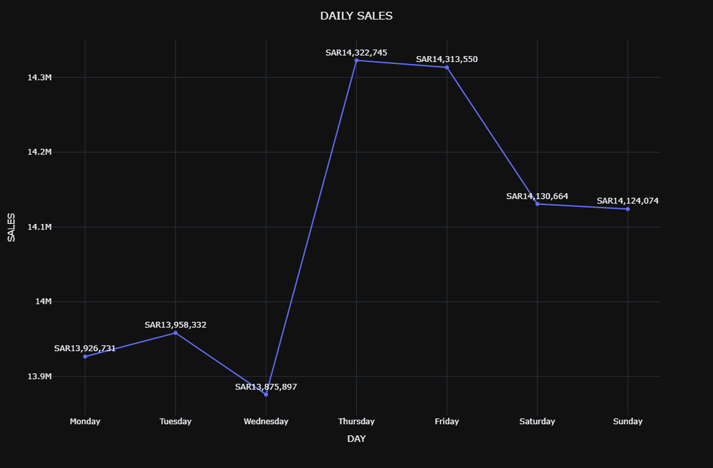

```python
day_order = ["Monday", "Tuesday", "Wednesday", "Thursday", "Friday", "Saturday", "Sunday"]

DAILY_SALES = pd.read_sql("""
SELECT Day_Name,
SUM([Total Sales]) AS TOTAL_SALES
FROM Interactive_Dashboards_Start
GROUP BY Day_Name;
""", engine)

fig = px.line(DAILY_SALES
.assign(Day_Name=lambda x: pd.Categorical(x["Day_Name"], categories=day_order, ordered=True)).sort_values("Day_Name"),
x="Day_Name", y="TOTAL_SALES", markers=True, text="TOTAL_SALES")

fig.update_traces(texttemplate="SAR%{text:,.0f}", textposition="top center", cliponaxis=True)
fig.update_layout(title="DAILY SALES", title_x=0.5,xaxis_title="DAY", yaxis_title="SALES",height=700, width=1100, template="plotly_dark")

fig.show()
```

**MONTHLY SALES**

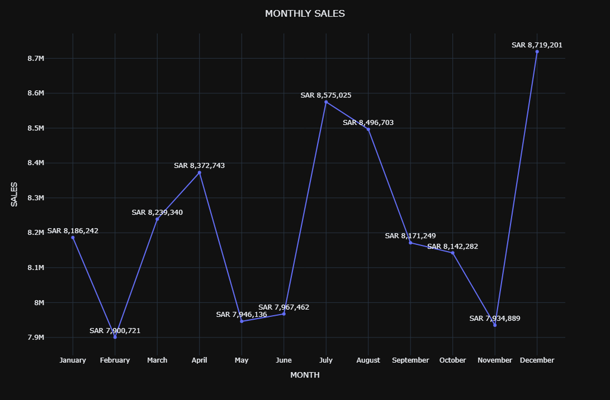

```python
month_order = ["January", "February", "March", "April", "May", "June", "July", "August","September", "October", "November", "December"]

MONTHLY_SALES = pd.read_sql("""
SELECT Month_Name,
SUM([Total Sales]) AS TOTAL_SALES
FROM Interactive_Dashboards_Start
GROUP BY Month_Name;
""", engine)

fig = px.line(MONTHLY_SALES
.assign(Month_Name=lambda x: pd.Categorical(x["Month_Name"], categories=month_order, ordered=True)).sort_values("Month_Name"),
x="Month_Name", y="TOTAL_SALES", markers=True, text="TOTAL_SALES")

fig.update_traces(texttemplate="SAR %{text:,.0f}", textposition="top center", cliponaxis=True)
fig.update_layout(title="MONTHLY SALES", title_x=0.5,xaxis_title="MONTH", yaxis_title="SALES",height=700, width=1100, template="plotly_dark")

fig.show()
```

**TOP TEN CUSTOMERS BY SALES**

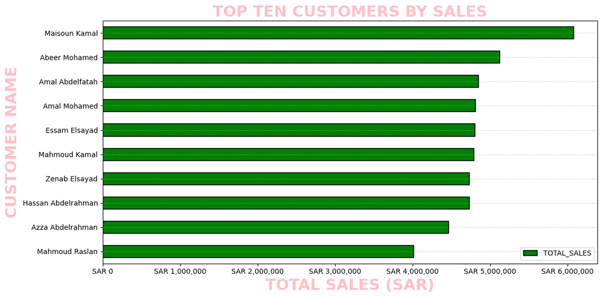

```python
import matplotlib.ticker as mticker

CUST_BY_SALES = pd.read_sql("""
SELECT TOP 10 [Customer Name],
SUM([Total Sales]) AS TOTAL_SALES
FROM Interactive_Dashboards_Start
GROUP BY [Customer Name]
ORDER BY TOTAL_SALES DESC;
""", engine)


CUST_BY_SALES = CUST_BY_SALES.sort_values("TOTAL_SALES")

ax = CUST_BY_SALES.plot.barh(x="Customer Name", y="TOTAL_SALES",
                              color="green", edgecolor="black", linewidth=1.2, figsize=(12,6))

plt.title("TOP TEN CUSTOMERS BY SALES", color="pink", fontsize=22, fontweight="bold")
plt.xlabel("TOTAL SALES (SAR)", color="pink", fontsize=22, fontweight="bold")
plt.ylabel("CUSTOMER NAME", color="pink", fontsize=22, fontweight="bold")


ax.xaxis.set_major_formatter(mticker.FuncFormatter(lambda x, _: f"SAR {x:,.0f}"))

plt.grid(linestyle="--", axis="y", alpha=0.5)
plt.tight_layout()
plt.show()
```

**TOP TEN PRODUCTS BY SALES**

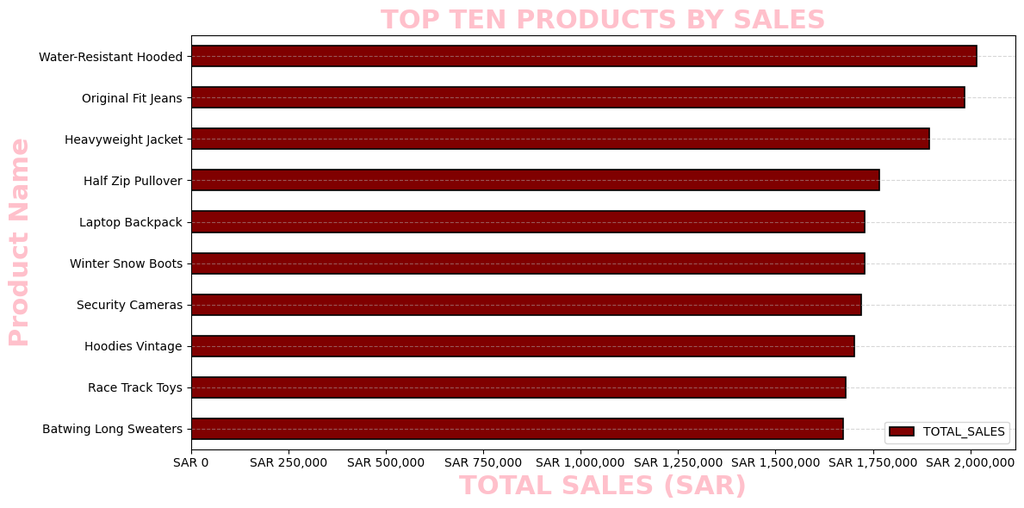

```python
import matplotlib.ticker as mticker

CUST_BY_SALES = pd.read_sql("""
SELECT TOP 10 [Product Name],
SUM([Total Sales]) AS TOTAL_SALES
FROM Interactive_Dashboards_Start
GROUP BY [Product Name]
ORDER BY TOTAL_SALES DESC;
""", engine)

CUST_BY_SALES = CUST_BY_SALES.sort_values("TOTAL_SALES")

ax = CUST_BY_SALES.plot.barh(x="Product Name", y="TOTAL_SALES",
                              color="maroon", edgecolor="black", linewidth=1.2, figsize=(12,6))

plt.title("TOP TEN PRODUCTS BY SALES", color="pink", fontsize=22, fontweight="bold")
plt.xlabel("TOTAL SALES (SAR)", color="pink", fontsize=22, fontweight="bold")
plt.ylabel("Product Name", color="pink", fontsize=22, fontweight="bold")


ax.xaxis.set_major_formatter(mticker.FuncFormatter(lambda x, _: f"SAR {x:,.0f}"))

plt.grid(linestyle="--", axis="y", alpha=0.5)
plt.tight_layout()
plt.show()
```

**TOP TEN CATEGORIES BY SALES**

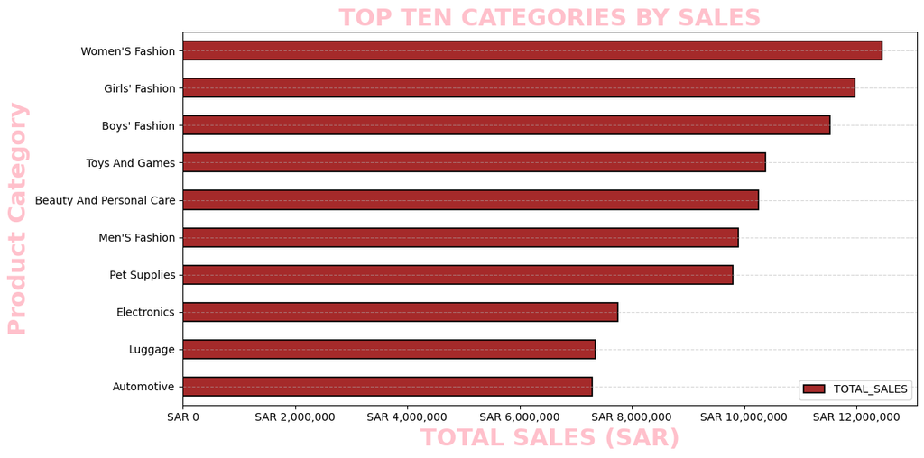

```python
import matplotlib.ticker as mticker

CUST_BY_SALES = pd.read_sql("""
SELECT TOP 10 [Product Category],
SUM([Total Sales]) AS TOTAL_SALES
FROM Interactive_Dashboards_Start
GROUP BY [Product Category]
ORDER BY TOTAL_SALES DESC;
""", engine)

CUST_BY_SALES = CUST_BY_SALES.sort_values("TOTAL_SALES")

ax = CUST_BY_SALES.plot.barh(x="Product Category", y="TOTAL_SALES",
                              color="brown", edgecolor="black", linewidth=1.2, figsize=(12,6))

plt.title("TOP TEN CATEGORIES BY SALES", color="pink", fontsize=22, fontweight="bold")
plt.xlabel("TOTAL SALES (SAR)", color="pink", fontsize=22, fontweight="bold")
plt.ylabel("Product Category", color="pink", fontsize=22, fontweight="bold")


ax.xaxis.set_major_formatter(mticker.FuncFormatter(lambda x, _: f"SAR {x:,.0f}"))

plt.grid(linestyle="--", axis="y", alpha=0.5)
plt.tight_layout()
plt.show()
```

**SALES PERFORMANCE DASHBOARD**

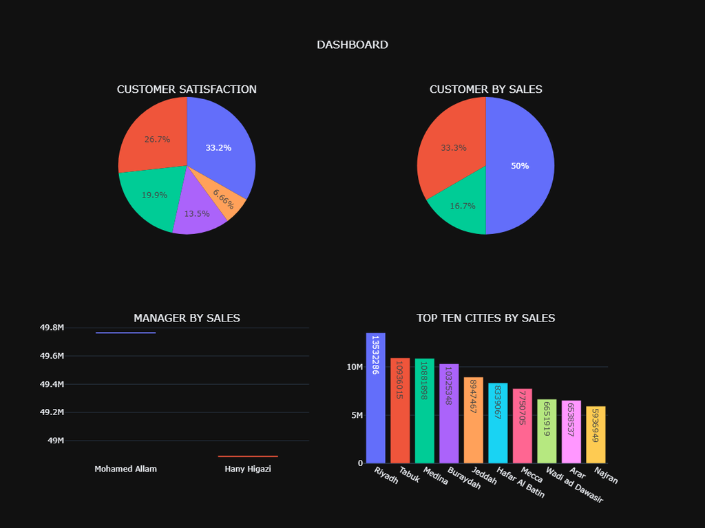

```python
CUSTOMER_SATISFACTION = pd.read_sql("""

SELECT [Customer Satisfaction],
SUM([Total Sales]) AS TOTAL_SALES
FROM Interactive_Dashboards_Start
GROUP BY [Customer Satisfaction]
ORDER BY TOTAL_SALES DESC;

""", engine)


CUSTOMER_TYPE_BY_SALES = pd.read_sql("""

SELECT [Customer Type],
SUM([Total Sales]) AS TOTAL_SALES
FROM Interactive_Dashboards_Start
GROUP BY [Customer Type]
ORDER BY TOTAL_SALES DESC;

""", engine)

MANAGER_BY_SALES = pd.read_sql("""

SELECT [Manager Name],
SUM([Total Sales]) AS TOTAL_SALES
FROM Interactive_Dashboards_Start
GROUP BY [Manager Name]
ORDER BY TOTAL_SALES DESC;

""", engine)

CITY_BY_SALES = pd.read_sql("""

SELECT TOP 10 City,
SUM([Total Sales]) AS TOTAL_SALES
FROM Interactive_Dashboards_Start
GROUP BY City
ORDER BY TOTAL_SALES DESC;

""", engine)


from plotly.subplots import make_subplots
import plotly.graph_objects as go
import plotly.express as px

specs = [[{"type": "domain"}, {"type": "domain"}],
         [{"type": "xy"},     {"type": "xy"}]]

fig = make_subplots(
    rows=2, cols=2,
    specs=specs,
    subplot_titles=("CUSTOMER SATISFACTION", "CUSTOMER BY SALES",
                     "MANAGER BY SALES", "TOP TEN CITIES BY SALES")
)

def add(f, row, col):
    for tr in f.data:
        fig.add_trace(tr, row=row, col=col)
add(px.pie(CUSTOMER_SATISFACTION, names="Customer Satisfaction", values="TOTAL_SALES", color="Customer Satisfaction"), 1, 1)
add(px.pie(CUSTOMER_TYPE_BY_SALES, names="Customer Type", values="TOTAL_SALES", color="Customer Type"), 1, 2)
add(px.box(MANAGER_BY_SALES, x="Manager Name", y="TOTAL_SALES", color="Manager Name"), 2, 1)
add(px.bar(CITY_BY_SALES, x="City", y="TOTAL_SALES", color="City", text="TOTAL_SALES"), 2, 2)


fig.update_layout(
    title={"text": "DASHBOARD", "x": 0.5},
    height=800, width=1100,
    template="plotly_dark",
    showlegend=False,
    margin=dict(l=100, r=150, t=150, b=100)
)

fig.show()
```

**KPI CARDS**

```python
from IPython.display import HTML

TOTAL_SALES = pd.read_sql("""
SELECT SUM([Total Sales]) AS TOTAL_SALES
FROM Interactive_Dashboards_Start
""", engine)

UNIQUE_CUSTOMERS = pd.read_sql("""
SELECT COUNT(DISTINCT [Customer Name]) AS TOTAL_CUSTOMERS
FROM Interactive_Dashboards_Start
""", engine)

TOTAL_ORDERS = pd.read_sql("""
SELECT COUNT([Invoice ID]) AS TOTAL_ORDERS
FROM Interactive_Dashboards_Start
""", engine)

AVERAGE_SALES = pd.read_sql("""
SELECT AVG([Total Sales]) AS AVERAGE_SALES
FROM Interactive_Dashboards_Start
""", engine)

display(HTML(f"""
<style>
body{{background:black; font-family:Arial, sans-serif;}}

.container{{display:flex;gap:30px;padding:30px;flex-wrap:wrap;justify-content:center;background:black;}}

.card{{width:250px;padding:30px;text-align:center;border-radius:30px;color:pink;background:linear-gradient(150deg, #1a1a1a, #2e2e2e);
box-shadow:4px 4px 10px hotpink;transition:0.5s;}}

.card:hover{{transform:translateY(-10px) scale(1.05);box-shadow:0 20px 40px hotpink;}}

.title{{font-size:25px;letter-spacing:1px;}}

.value{{font-size:40px;font-weight:bold;}}
</style>

<div class="container">

<div class="card">
<h2 class="title">TOTAL SALES</h2>
<h1 class="value">SAR {TOTAL_SALES.iloc[0,0]:,.0f}</h1>
</div>

<div class="card">
<h2 class="title">UNIQUE CUSTOMERS</h2>
<h1 class="value">{UNIQUE_CUSTOMERS.iloc[0,0]:,}</h1>
</div>

<div class="card">
<h2 class="title">TOTAL ORDERS</h2>
<h1 class="value">{TOTAL_ORDERS.iloc[0,0]:,}</h1>
</div>

<div class="card">
<h2 class="title">AVERAGE SALES</h2>
<h1 class="value">{AVERAGE_SALES.iloc[0,0]:,}</h1>
</div>

</div>
"""))
```

TOTAL SALES

SAR 98,651,993

UNIQUE CUSTOMERS

26

TOTAL ORDERS

49,998

AVERAGE SALES

1,973

# CONCLUSION — STORE SALES IN SAUDI ARABIA

The analysis of 49,998 sales records shows total sales of **SAR 98.65M**. The analysis identified important patterns across customers, cities, products, product categories, sales channels, customer satisfaction, managers, and sales trends.

- **Online** is the dominant sales channel, generating approximately **SAR 92.07M**, compared with **SAR 6.58M** from Store sales.
- **Riyadh** recorded the highest city sales at approximately **SAR 13.53M**.
- **Women's Fashion** was the highest-performing product category, generating approximately **SAR 12.46M**.
- **Water-Resistant Hooded** was the highest-selling individual product, generating approximately **SAR 2.01M**.
- **Maisoun Kamal** was the highest-selling customer, with approximately **SAR 6.08M** in sales.
- **Male customers** recorded higher total sales than female customers.
- **2022** was the strongest year, generating approximately **SAR 25.02M** in sales, while **2023** generated approximately **SAR 24.72M**.
- **Mohamed Allam** recorded approximately **SAR 49.76M** in sales, slightly higher than **Hany Higazi**, who recorded approximately **SAR 48.89M**.
- Customer satisfaction was led by the **High** category, with 16,783 records, followed by **Ok** with 13,209 records.

Overall, the business shows strong sales performance, particularly through the online channel, with Riyadh and Women's Fashion being important contributors to revenue. The year-level analysis also shows relatively stable sales across 2020–2023, with 2022 recording the highest annual sales.

# BUSINESS RECOMMENDATIONS

### 1. Strengthen the Online Channel

Online sales generate the majority of revenue. The business should continue investing in digital marketing, website performance, customer retention, and online conversion strategies while monitoring online sales KPIs regularly.

### 2. Expand Women's Fashion

Women's Fashion is the highest-performing product category. The business should maintain sufficient inventory for high-performing products and use targeted promotions and cross-selling to increase category revenue.

### 3. Focus on High-Performing Cities

Riyadh is the strongest city by sales. The business should identify the factors driving Riyadh's performance and apply successful strategies to lower-performing cities.

### 4. Improve Store Sales

Store sales are substantially lower than online sales. The business should investigate store-level performance, product availability, promotions, and customer behavior to identify opportunities to increase physical-store revenue.

### 5. Protect Customer Satisfaction

The largest customer-satisfaction group is "High," which indicates a strong positive customer experience. The business should maintain service quality while investigating the customers in the Low and Very Low satisfaction groups to identify areas for improvement.

### 6. Monitor Yearly Sales Performance

Sales were relatively stable from 2020 to 2023, with 2022 recording the highest annual sales. Management should monitor monthly and yearly trends to identify periods of growth or decline and adjust marketing, inventory, and sales strategies accordingly.